# SMU MSDS 2008 Summer Case Study2

Rene, Chaoshun and Mahesh

July 24, 2018

## Description

DDSAnalytics is an analytics company that specializes in talent management solutions for Fortune 1000 companies. Talent management is defined as the iterative process of developing and retaining programs, identifying high-potential employees and reducing/preventing voluntary employee turnover(attrition). To gain a competitive edge over its competition, DDSAnalytics is planning to leverage data science for talent management. The executive leadership has identified predicting employee turnover as its first application of data science for talent management. Before the business green lights the project, they have tasked your data science team to conduct an analysis of existing employee data.

A dataset(casestudy2.csv) has been converted from original xlsx dataset for us to conduct exploratory data analysis (EDA) to determine factors that lead to attrition.

We should identify (at least) the top three factors that contribute to turnover. There may or may not be a need to create derived attribute/variables.

The business is also interested in learning about any job role specific trends that may exist in the data set. we can also provide any other interesting trends and observations from our analysis.

#### The analysis should be backed up by robust experimentation and (where applicable) appropriate visualization.

Experiments, analysis and visualization must be conducted in R.

## Deliverable:

Create a GitHub repository with an RMarkdown file containing an executive summary, introduction to the project, all supporting code and analysis, and the group presentation.

Submit a link to the GitHub repository via the space provided for the Case Study 02 page in 2DS.

NO CODE should be present in your presentation. (ie variable names is Mon_Age this should in your presentation as age). You code should be in your GitHub and RMarkdown File.

```r
summary(talentManage)
```

```
##       Age        Attrition            BusinessTravel   DailyRate
##  Min.   :18.00   No :1233   Non-Travel       : 150   Min.   : 102.0
##  1st Qu.:30.00   Yes: 237   Travel_Frequently: 277   1st Qu.: 465.0
##  Median :36.00              Travel_Rarely    :1043   Median : 802.0
##  Mean   :36.92                                       Mean   : 802.5
##  3rd Qu.:43.00                                       3rd Qu.:1157.0
##  Max.   :60.00                                       Max.   :1499.0
##
##                   Department  DistanceFromHome   Education
##  Human Resources       : 63   Min.   : 1.000   Min.   :1.000
##  Research & Development:961   1st Qu.: 2.000   1st Qu.:2.000
##  Sales                 :446   Median : 7.000   Median :3.000
##                               Mean   : 9.193   Mean   :2.913
##                               3rd Qu.:14.000   3rd Qu.:4.000
##                               Max.   :29.000   Max.   :5.000
##
##           EducationField EmployeeCount EmployeeNumber
##  Human Resources : 27    Min.   :1     Min.   :   1.0
##  Life Sciences   :606    1st Qu.:1     1st Qu.: 491.2
##  Marketing       :159    Median :1     Median :1020.5
##  Medical         :464    Mean   :1     Mean   :1024.9
##  Other           : 82    3rd Qu.:1     3rd Qu.:1555.8
##  Technical Degree:132    Max.   :1     Max.   :2068.0
##
##  EnvironmentSatisfaction    Gender      HourlyRate     JobInvolvement
##  Min.   :1.000           Female:588   Min.   : 30.00   Min.   :1.00
##  1st Qu.:2.000           Male  :882   1st Qu.: 48.00   1st Qu.:2.00
##  Median :3.000                        Median : 66.00   Median :3.00
##  Mean   :2.722                        Mean   : 65.89   Mean   :2.73
##  3rd Qu.:4.000                        3rd Qu.: 83.75   3rd Qu.:3.00
##  Max.   :4.000                        Max.   :100.00   Max.   :4.00
##
##     JobLevel                          JobRole    JobSatisfaction
##  Min.   :1.000   Sales Executive          :326   Min.   :1.000
##  1st Qu.:1.000   Research Scientist       :292   1st Qu.:2.000
##  Median :2.000   Laboratory Technician    :259   Median :3.000
##  Mean   :2.064   Manufacturing Director   :145   Mean   :2.729
##  3rd Qu.:3.000   Healthcare Representative:131   3rd Qu.:4.000
##  Max.   :5.000   Manager                  :102   Max.   :4.000
##                  (Other)                  :215
```

[output cut: 25 more lines]

```
##  Min.   :0.000         Min.   :1.000   Min.   : 0.000   Min.   : 0.000
##  1st Qu.:2.000         1st Qu.:2.000   1st Qu.: 3.000   1st Qu.: 2.000
##  Median :3.000         Median :3.000   Median : 5.000   Median : 3.000
##  Mean   :2.799         Mean   :2.761   Mean   : 7.008   Mean   : 4.229
##  3rd Qu.:3.000         3rd Qu.:3.000   3rd Qu.: 9.000   3rd Qu.: 7.000
##  Max.   :6.000         Max.   :4.000   Max.   :40.000   Max.   :18.000
##
##  YearsSinceLastPromotion YearsWithCurrManager
##  Min.   : 0.000          Min.   : 0.000
##  1st Qu.: 0.000          1st Qu.: 2.000
##  Median : 1.000          Median : 3.000
##  Mean   : 2.188          Mean   : 4.123
##  3rd Qu.: 3.000          3rd Qu.: 7.000
##  Max.   :15.000          Max.   :17.000
##
```

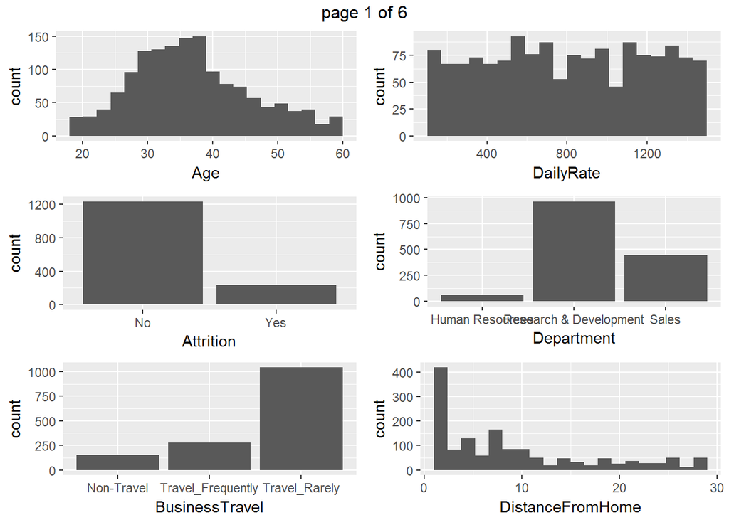

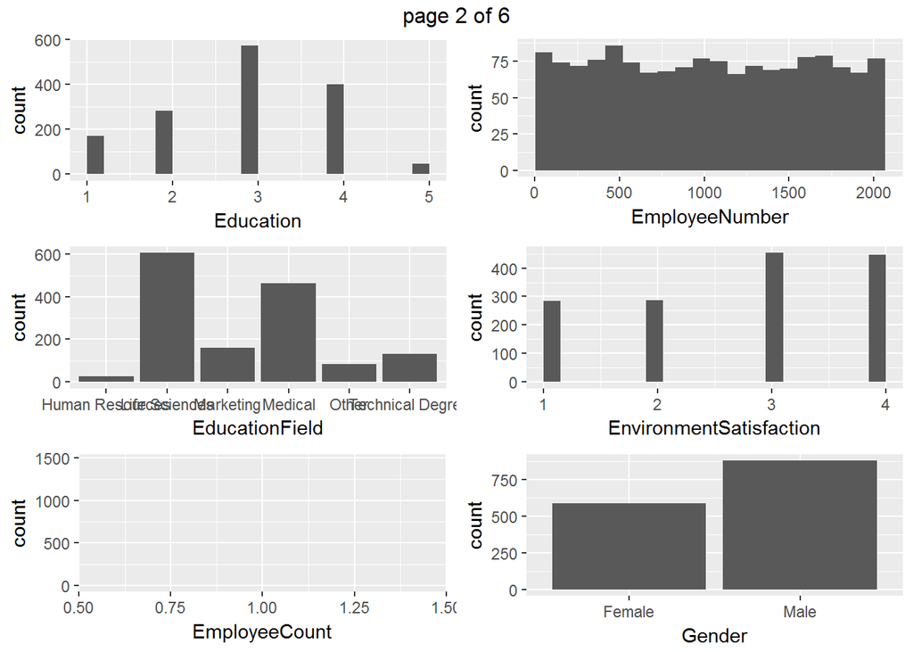

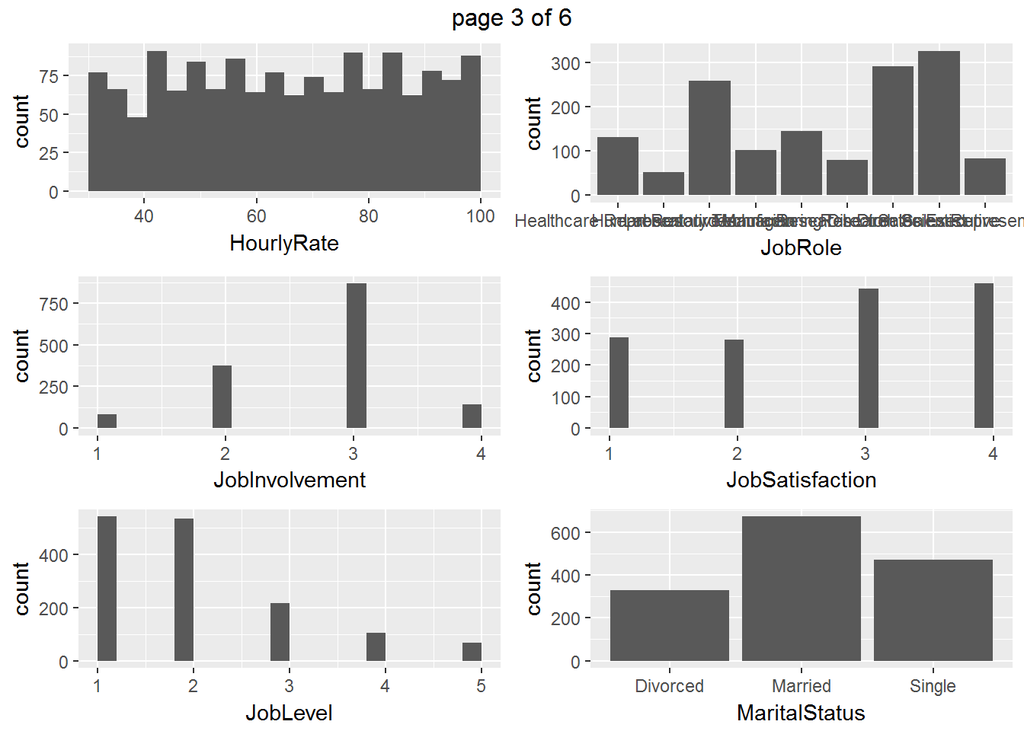

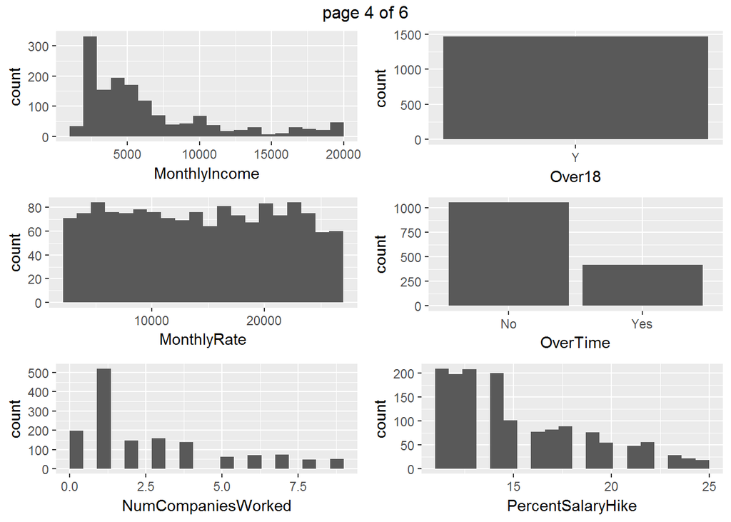

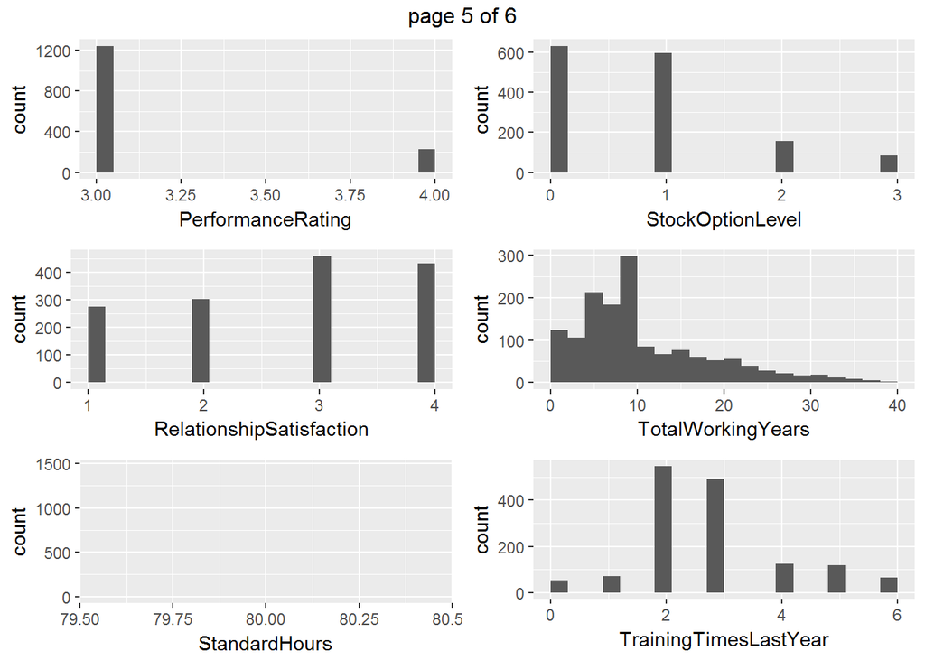

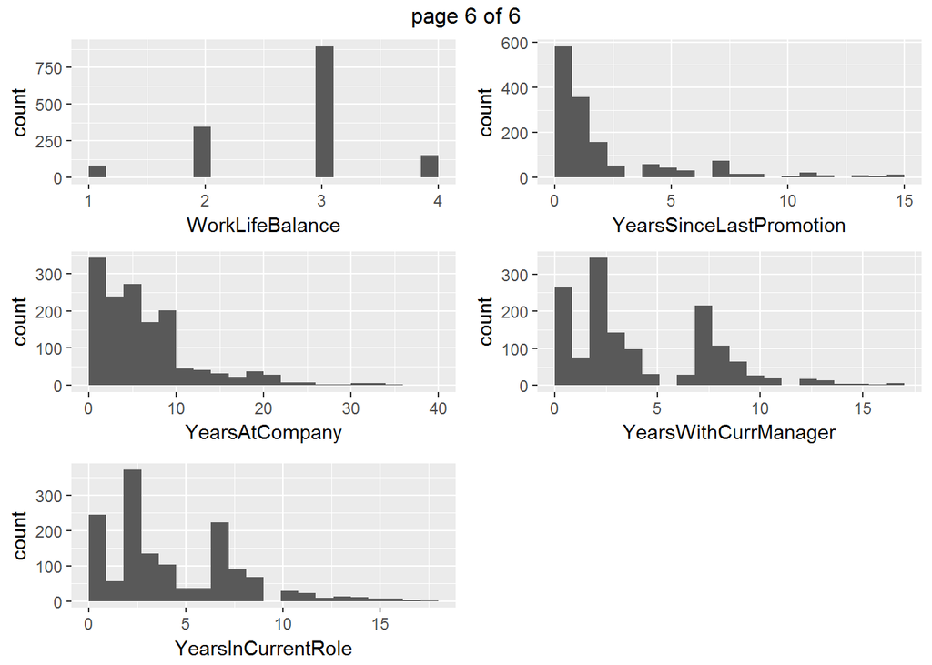

```r
require(dataMaid)
visualize(talentManage)
```

## Tasks

### 1. Formulate your Repo

a The client wants this to be reproducible and know exactly what you did. There needs to be an informative Readme, complete with several sections, as referenced in Live Session. Give contact information, session Info, and the objective of the repo at least.

SMU MSDS 6306 Doing Data Science (Section#405) Case Study 2

GitHub: https://github.com/chaoshunh/SMU_MSDS/Doing_Data_Science/CaseStudy2.git

The objectivity of this project was to to conduct exploratory data analysis (EDA) to determine factors that lead to attrition based on multiple regression

Rene | email: @mail.smu.edu phone: 50374708866

Chaoshun | email: chaoshunh@mail.smu.edu phone: 7138762786

Mehesh | email: @mail.smu.edu phone: 2397287762

b You have a large data set, and it needs its own Codebook, formatted in an approachable way. Make sure you describe peculiarities of the data by variable and what needs transforming. However, do not make it too long either.

c Create a file structure that is accessible and transparent. Document it in the root directory, ideally in the Readme.

### 2. Clean your Raw Data

a Read the csv into R and take a look at the data set. Output how many rows and columns the data.frame is.

```r
dim(talentManage)
```

```
## [1] 1470   35
```

b The column names are either too much or not enough. Change the column names so that they do not have spaces, underscores, slashes, and the like. All column names should be under 12 characters. Make sure youâre updating your codebook with information on the tidied data set as well.

```r
colnames(talentManage)
```

```
##  [1] "Age"                      "Attrition"
##  [3] "BusinessTravel"           "DailyRate"
##  [5] "Department"               "DistanceFromHome"
##  [7] "Education"                "EducationField"
##  [9] "EmployeeCount"            "EmployeeNumber"
## [11] "EnvironmentSatisfaction"  "Gender"
## [13] "HourlyRate"               "JobInvolvement"
## [15] "JobLevel"                 "JobRole"
## [17] "JobSatisfaction"          "MaritalStatus"
## [19] "MonthlyIncome"            "MonthlyRate"
## [21] "NumCompaniesWorked"       "Over18"
## [23] "OverTime"                 "PercentSalaryHike"
## [25] "PerformanceRating"        "RelationshipSatisfaction"
## [27] "StandardHours"            "StockOptionLevel"
## [29] "TotalWorkingYears"        "TrainingTimesLastYear"
## [31] "WorkLifeBalance"          "YearsAtCompany"
## [33] "YearsInCurrentRole"       "YearsSinceLastPromotion"
## [35] "YearsWithCurrManager"
```

```r
colnames(talentManage)=abbreviate(colnames(talentManage), method=c("both.sides"),minlength = 11)
colnames(talentManage)
```

```
##  [1] "Age"         "Attrition"   "BusinssTrvl" "DailyRate"   "Department"
##  [6] "DistncFrmHm" "Education"   "EducatinFld" "EmployeeCnt" "EmployeNmbr"
## [11] "EnvrnmntSts" "Gender"      "HourlyRate"  "JobInvlvmnt" "JobLevel"
## [16] "JobRole"     "JobSatsfctn" "MaritalStts" "MonthlyIncm" "MonthlyRate"
## [21] "NmCmpnsWrkd" "Over18"      "OverTime"    "PrcntSlryHk" "PrfrmncRtng"
## [26] "RltnshpStsf" "StandardHrs" "StckOptnLvl" "TtlWrkngYrs" "TrnngTmsLsY"
## [31] "WorkLifBlnc" "YersAtCmpny" "YrsInCrrntR" "YrsSncLstPr" "YrsWthCrrMn"
```

c Some columns are, due to Qualtrics, malfunctioning.

```r
require(dplyr)
talentManageNew<-talentManage %>% select(Age, Attrition, DistncFrmHm, Education, EnvrnmntSts,Gender, JobLevel,
                                         JobSatsfctn, MonthlyIncm, YersAtCmpny, YrsSncLstPr)
dim(talentManageNew)
```

```
## [1] 1470   11
```

d Make sure your columns are the proper data types (i.e., numeric, character, etc.). If they are incorrect, convert them.

### 3. Preliminary Analysis

a Remove all observations where the participant is under age 18. No further analysis of underage individuals is permitted by your client. Remove any other age outliers as you see fit, but be sure to tell what youâre doing and why.

b Please provide (in table format or similar), descriptive statistics on at least 7 variables (age, Income, etc.). Create a simple histogram for two of them. Comment on the shape of the distribution in your markdown.

c Give the frequencies (in table format or similar) for Gender, Education, and Occupation. They can be separate tables, if thatâs your choice.

d Give the counts (again, table) of management positions.

### 4. Deeper Analysis and Visualization

a Note: You should make all of these appealing looking. Remember to include things like a clean, informative title, axis labels that are in plain English, and readable axis values that do not overlap.

b Create bar charts in ggplot or similar. The bars should be in descending order, Use any color palette of your choice other than the default.

c Is there a relationship between Age and Income? Create a scatterplot and make an assessment of whether there is a relationship. Color each point based on the Gender of the participant. Youâre welcome to use lm() or similar functions to back up your claims.

d What about Life Satisfaction? Create another scatterplot. Is there a discernible relationship there to what?

```r
library(magrittr)
library(tidyverse)
library(broom)
talentManage <-read.csv("E:\\Mahesh\\SMU\\GitHub\\SMU_MSDS\\Doing_Data_Science\\CaseStudy2\\data\\casestudy2.csv")

colnames(talentManage)=abbreviate(colnames(talentManage), method=c("both.sides"),minlength = 11)

talentManage$Attrition <- factor(talentManage$Attrition, levels=c("No","Yes"), labels=c(0, 1))

#talentManage2 <- talentManage

#talentManage2$Attrition <- as.numeric(talentManage2$Attrition)
#talentManage2$BusinssTrvl <- as.numeric(talentManage2$BusinssTrvl)
#talentManage2$Department <- as.numeric(talentManage2$Department)
#talentManage2$EducatinFld <- as.numeric(talentManage2$EducatinFld)
#talentManage2$Gender <- as.numeric(talentManage2$Gender)
#talentManage2$JobRole <- as.numeric(talentManage2$JobRole)
#talentManage2$MaritalStts <- as.numeric(talentManage2$MaritalStts)
#talentManage2$Over18 <- as.numeric(talentManage2$Over18)
#talentManage2$OverTime <- as.numeric(talentManage2$OverTime)


model <- glm(Attrition~Age+Gender+BusinssTrvl+DailyRate+Department+DistncFrmHm+Education+EducatinFld+EnvrnmntSts+HourlyRate+JobInvlvmnt+JobLevel+JobRole+JobSatsfctn+MaritalStts+MonthlyIncm+MonthlyRate, data=talentManage, family=binomial(link=logit))
summary(model)
```

```
##
## Call:
## glm(formula = Attrition ~ Age + Gender + BusinssTrvl + DailyRate +
##     Department + DistncFrmHm + Education + EducatinFld + EnvrnmntSts +
##     HourlyRate + JobInvlvmnt + JobLevel + JobRole + JobSatsfctn +
##     MaritalStts + MonthlyIncm + MonthlyRate, family = binomial(link = logit),
##     data = talentManage)
##
## Deviance Residuals:
##     Min       1Q   Median       3Q      Max
## -1.5494  -0.5931  -0.3902  -0.1985   2.9442
##
## Coefficients:
##                                    Estimate Std. Error z value Pr(>|z|)
## (Intercept)                      -1.242e+01  4.218e+02  -0.029 0.976508
## Age                              -2.189e-02  1.063e-02  -2.059 0.039456
## GenderMale                        2.218e-01  1.641e-01   1.351 0.176625
## BusinssTrvlTravel_Frequently      1.596e+00  3.629e-01   4.399 1.09e-05
## BusinssTrvlTravel_Rarely          9.061e-01  3.384e-01   2.678 0.007408
## DailyRate                        -2.011e-04  1.979e-04  -1.016 0.309476
## DepartmentResearch & Development  1.303e+01  4.218e+02   0.031 0.975367
## DepartmentSales                   1.272e+01  4.218e+02   0.030 0.975951
## DistncFrmHm                       3.411e-02  9.346e-03   3.650 0.000262
## Education                         1.551e-02  7.957e-02   0.195 0.845467
## EducatinFldLife Sciences         -1.085e+00  7.365e-01  -1.473 0.140654
## EducatinFldMarketing             -7.464e-01  7.778e-01  -0.960 0.337248
## EducatinFldMedical               -1.217e+00  7.412e-01  -1.642 0.100620
## EducatinFldOther                 -1.228e+00  7.991e-01  -1.537 0.124224
## EducatinFldTechnical Degree      -4.188e-01  7.567e-01  -0.553 0.579969
## EnvrnmntSts                      -3.069e-01  7.200e-02  -4.263 2.02e-05
## HourlyRate                       -4.975e-04  3.916e-03  -0.127 0.898902
## JobInvlvmnt                      -5.031e-01  1.086e-01  -4.632 3.63e-06
## JobLevel                         -3.212e-01  2.587e-01  -1.242 0.214420
## JobRoleHuman Resources            1.382e+01  4.218e+02   0.033 0.973865
## JobRoleLaboratory Technician      1.236e+00  4.398e-01   2.811 0.004941
## JobRoleManager                    3.164e-01  8.146e-01   0.388 0.697709
## JobRoleManufacturing Director     2.026e-02  4.936e-01   0.041 0.967260
## JobRoleResearch Director         -9.536e-01  8.876e-01  -1.074 0.282697
## JobRoleResearch Scientist         7.199e-01  4.471e-01   1.610 0.107364
## JobRoleSales Executive            1.214e+00  1.037e+00   1.171 0.241468
```

[output cut: 34 more lines]

```
## JobSatsfctn                      ***
## MaritalSttsMarried
## MaritalSttsSingle                ***
## MonthlyIncm
## MonthlyRate
## ---
## Signif. codes:  0 '***' 0.001 '**' 0.01 '*' 0.05 '.' 0.1 ' ' 1
##
## (Dispersion parameter for binomial family taken to be 1)
##
##     Null deviance: 1298.6  on 1469  degrees of freedom
## Residual deviance: 1058.8  on 1438  degrees of freedom
## AIC: 1122.8
##
## Number of Fisher Scoring iterations: 14
```

```r
# remove over18 column from dataframe
talentManage[, c("Over18", "EmployeeCnt", "EmployeNmbr")] <- list(NULL)

model <- glm(Attrition~., data=talentManage, family=binomial(link=logit))
summary(model)
```

```
##
## Call:
## glm(formula = Attrition ~ ., family = binomial(link = logit),
##     data = talentManage)
##
## Deviance Residuals:
##     Min       1Q   Median       3Q      Max
## -1.6450  -0.4836  -0.2532  -0.0897   3.3695
##
## Coefficients: (1 not defined because of singularities)
##                                    Estimate Std. Error z value Pr(>|z|)
## (Intercept)                      -1.063e+01  3.838e+02  -0.028  0.97790
## Age                              -3.088e-02  1.354e-02  -2.281  0.02256
## BusinssTrvlTravel_Frequently      1.912e+00  4.124e-01   4.636 3.55e-06
## BusinssTrvlTravel_Rarely          1.032e+00  3.801e-01   2.716  0.00661
## DailyRate                        -2.809e-04  2.202e-04  -1.276  0.20212
## DepartmentResearch & Development  1.274e+01  3.838e+02   0.033  0.97351
## DepartmentSales                   1.258e+01  3.838e+02   0.033  0.97385
## DistncFrmHm                       4.529e-02  1.077e-02   4.205 2.61e-05
## Education                         3.870e-03  8.761e-02   0.044  0.96477
## EducatinFldLife Sciences         -7.338e-01  8.044e-01  -0.912  0.36167
## EducatinFldMarketing             -3.353e-01  8.532e-01  -0.393  0.69432
## EducatinFldMedical               -8.256e-01  8.040e-01  -1.027  0.30450
## EducatinFldOther                 -8.040e-01  8.639e-01  -0.931  0.35203
## EducatinFldTechnical Degree       1.930e-01  8.226e-01   0.235  0.81445
## EnvrnmntSts                      -4.352e-01  8.289e-02  -5.250 1.52e-07
## GenderMale                        3.974e-01  1.846e-01   2.153  0.03131
## HourlyRate                        1.055e-03  4.410e-03   0.239  0.81093
## JobInvlvmnt                      -5.253e-01  1.225e-01  -4.288 1.80e-05
## JobLevel                         -8.424e-02  3.161e-01  -0.267  0.78984
## JobRoleHuman Resources            1.400e+01  3.838e+02   0.036  0.97090
## JobRoleLaboratory Technician      1.486e+00  4.837e-01   3.071  0.00213
## JobRoleManager                    3.550e-01  8.899e-01   0.399  0.68992
## JobRoleManufacturing Director     2.251e-01  5.327e-01   0.422  0.67267
## JobRoleResearch Director         -1.091e+00  1.008e+00  -1.082  0.27931
## JobRoleResearch Scientist         5.381e-01  4.951e-01   1.087  0.27706
## JobRoleSales Executive            1.194e+00  1.125e+00   1.061  0.28850
## JobRoleSales Representative       2.147e+00  1.179e+00   1.822  0.06852
## JobSatsfctn                      -4.112e-01  8.151e-02  -5.046 4.52e-07
## MaritalSttsMarried                3.242e-01  2.669e-01   1.215  0.22443
```

[output cut: 59 more lines]

```
## WorkLifBlnc                      **
## YersAtCmpny                      *
## YrsInCrrntR                      **
## YrsSncLstPr                      ***
## YrsWthCrrMn                      **
## ---
## Signif. codes:  0 '***' 0.001 '**' 0.01 '*' 0.05 '.' 0.1 ' ' 1
##
## (Dispersion parameter for binomial family taken to be 1)
##
##     Null deviance: 1298.58  on 1469  degrees of freedom
## Residual deviance:  859.01  on 1425  degrees of freedom
## AIC: 949.01
##
## Number of Fisher Scoring iterations: 14
```

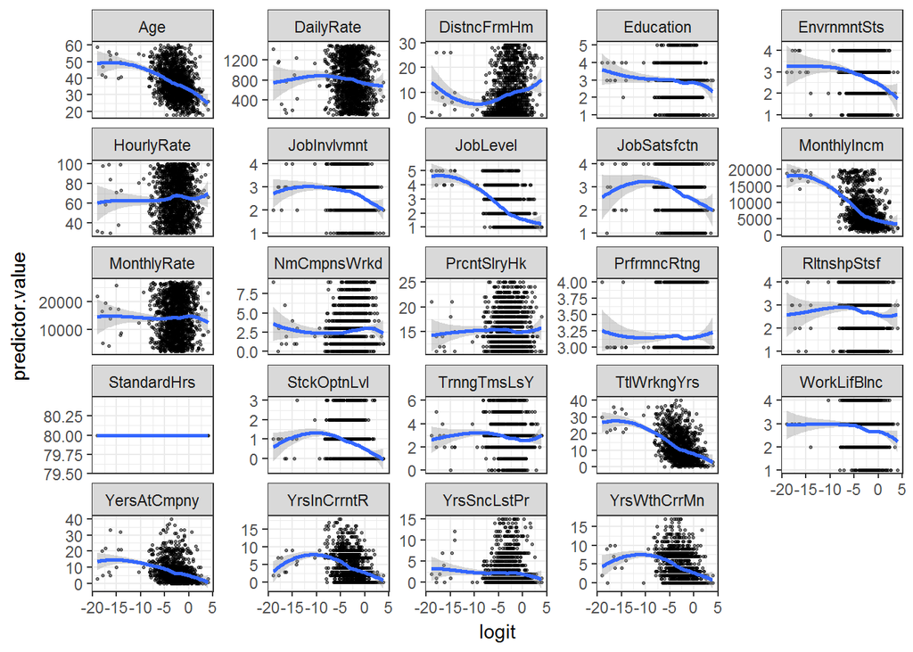

```r
probabilities <- predict(model, type = "response")

mydata <- talentManage %>%
  dplyr::select_if(is.numeric)
predictors <- colnames(mydata)
# Bind the logit and tidying the data for plot
mydata <- mydata %>%
  mutate(logit = log(probabilities/(1-probabilities))) %>%
  tidyr::gather(key = "predictors", value = "predictor.value", -logit)
ggplot(mydata, aes(logit, predictor.value))+
  geom_point(size = 0.5, alpha = 0.5) +
  geom_smooth(method = "loess") +
  theme_bw() +
  facet_wrap(~predictors, scales = "free_y")
```

```r
#Std.resid and cooks distance broom package augment
model.data <- augment(model) %>%
  mutate(index = 1:n())

#The data for the top 3 largest values, according to the Cook's distance, can be displayed as follow
model.data %>% top_n(3, .cooksd)
```

```
##   Attrition Age   BusinssTrvl DailyRate             Department DistncFrmHm
## 1         1  41 Travel_Rarely      1360 Research & Development          12
## 2         1  58 Travel_Rarely       147 Research & Development          23
## 3         1  53 Travel_Rarely       607 Research & Development           2
##   Education      EducatinFld EnvrnmntSts Gender HourlyRate JobInvlvmnt
## 1         3 Technical Degree           2 Female         49           3
## 2         4          Medical           4 Female         94           3
## 3         5 Technical Degree           3 Female         78           2
##   JobLevel                   JobRole JobSatsfctn MaritalStts MonthlyIncm
## 1        5         Research Director           3     Married       19545
## 2        3 Healthcare Representative           4     Married       10312
## 3        3    Manufacturing Director           4     Married       10169
##   MonthlyRate NmCmpnsWrkd OverTime PrcntSlryHk PrfrmncRtng RltnshpStsf
## 1       16280           1       No          12           3           4
## 2        3465           1       No          12           3           4
## 3       14618           0       No          16           3           2
##   StandardHrs StckOptnLvl TtlWrkngYrs TrnngTmsLsY WorkLifBlnc YersAtCmpny
## 1          80           0          23           0           3          22
## 2          80           1          40           3           2          40
## 3          80           1          34           4           3          33
##   YrsInCrrntR YrsSncLstPr YrsWthCrrMn   .fitted  .se.fit   .resid
## 1          15          15           8 -4.140783 1.057595 2.883251
## 2          10          15           6 -3.705907 1.088471 2.731369
## 3           7           1           9 -5.398749 1.050742 3.287327
##          .hat    .sigma    .cooksd .std.resid index
## 1 0.017242850 0.7728498 0.02493580   2.908435    46
## 2 0.027738877 0.7732067 0.02653172   2.770058   127
## 3 0.004947964 0.7717581 0.02455666   3.295490  1112
```

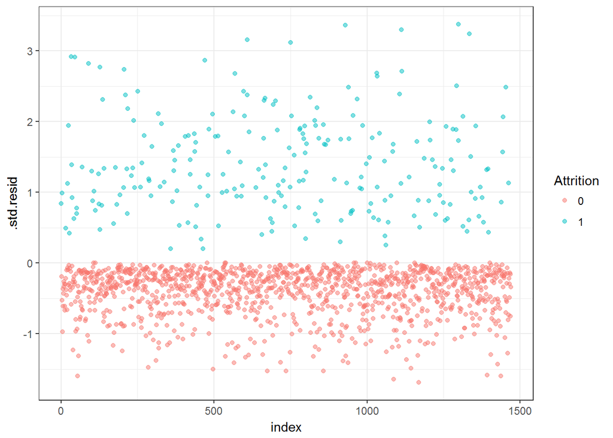

```r
#Plot the standardized residuals:
ggplot(model.data, aes(index, .std.resid)) +
  geom_point(aes(color = Attrition), alpha = .5) +
  theme_bw()
```

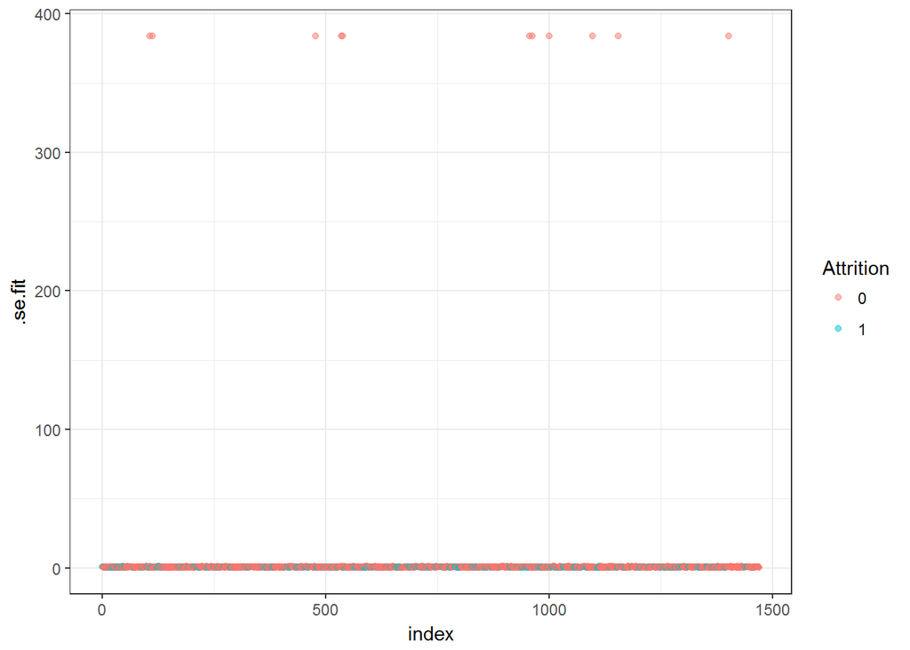

```r
ggplot(model.data, aes(index, .se.fit)) +
  geom_point(aes(color = Attrition), alpha = .5) +
  theme_bw()
```

```r
# Check for multi-collinearlity
#car::vif(model)
```